# FItBit-Analysis

Satyendra Singh

2022-05-18

##ANALYISIS ON FITBIT FITNESS TRACKER DATA

#OBJECTIVE- HOW CAN A WELLNESS TECHNOLOGY COMPANY(Bellabeat) PLAY IT SMART ?

##IMPORTING LIBRARIES

```r
library(ggplot2)
```

```r
library(dplyr)
#install.packages("skimr") for generating summary of the dataset
library(skimr)
```

```r
#install.packages("janitor") for cleaning the dirty dataset
library(janitor)
library(tidyverse)
library(lubridate)
library(stringr)
```

#Importing the required dataset

```r
daily_activity<-read_csv("D:/google cert/case_2/dailyActivity_merged.csv")
str(daily_activity)
```

```
## spec_tbl_df [940 x 15] (S3: spec_tbl_df/tbl_df/tbl/data.frame)
##  $ Id                      : num [1:940] 1.5e+09 1.5e+09 1.5e+09 1.5e+09 1.5e+09 ...
##  $ ActivityDate            : chr [1:940] "4/12/2016" "4/13/2016" "4/14/2016" "4/15/2016" ...
##  $ TotalSteps              : num [1:940] 13162 10735 10460 9762 12669 ...
##  $ TotalDistance           : num [1:940] 8.5 6.97 6.74 6.28 8.16 ...
##  $ TrackerDistance         : num [1:940] 8.5 6.97 6.74 6.28 8.16 ...
##  $ LoggedActivitiesDistance: num [1:940] 0 0 0 0 0 0 0 0 0 0 ...
##  $ VeryActiveDistance      : num [1:940] 1.88 1.57 2.44 2.14 2.71 ...
##  $ ModeratelyActiveDistance: num [1:940] 0.55 0.69 0.4 1.26 0.41 ...
##  $ LightActiveDistance     : num [1:940] 6.06 4.71 3.91 2.83 5.04 ...
##  $ SedentaryActiveDistance : num [1:940] 0 0 0 0 0 0 0 0 0 0 ...
##  $ VeryActiveMinutes       : num [1:940] 25 21 30 29 36 38 42 50 28 19 ...
##  $ FairlyActiveMinutes     : num [1:940] 13 19 11 34 10 20 16 31 12 8 ...
##  $ LightlyActiveMinutes    : num [1:940] 328 217 181 209 221 164 233 264 205 211 ...
##  $ SedentaryMinutes        : num [1:940] 728 776 1218 726 773 ...
##  $ Calories                : num [1:940] 1985 1797 1776 1745 1863 ...
##  - attr(*, "spec")=
##   .. cols(
##   ..   Id = col_double(),
##   ..   ActivityDate = col_character(),
##   ..   TotalSteps = col_double(),
##   ..   TotalDistance = col_double(),
##   ..   TrackerDistance = col_double(),
##   ..   LoggedActivitiesDistance = col_double(),
##   ..   VeryActiveDistance = col_double(),
##   ..   ModeratelyActiveDistance = col_double(),
##   ..   LightActiveDistance = col_double(),
##   ..   SedentaryActiveDistance = col_double(),
##   ..   VeryActiveMinutes = col_double(),
##   ..   FairlyActiveMinutes = col_double(),
##   ..   LightlyActiveMinutes = col_double(),
##   ..   SedentaryMinutes = col_double(),
##   ..   Calories = col_double()
##   .. )
##  - attr(*, "problems")=<externalptr>
```

```r
daily_sleep<-read_csv("D:/google cert/case_2/sleepDay_merged.csv")
str(daily_sleep)
```

```
## spec_tbl_df [413 x 5] (S3: spec_tbl_df/tbl_df/tbl/data.frame)
##  $ Id                : num [1:413] 1.5e+09 1.5e+09 1.5e+09 1.5e+09 1.5e+09 ...
##  $ SleepDay          : chr [1:413] "4/12/2016 12:00:00 AM" "4/13/2016 12:00:00 AM" "4/15/2016 12:00:00 AM" "4/16/2016 12:00:00 AM" ...
##  $ TotalSleepRecords : num [1:413] 1 2 1 2 1 1 1 1 1 1 ...
##  $ TotalMinutesAsleep: num [1:413] 327 384 412 340 700 304 360 325 361 430 ...
##  $ TotalTimeInBed    : num [1:413] 346 407 442 367 712 320 377 364 384 449 ...
##  - attr(*, "spec")=
##   .. cols(
##   ..   Id = col_double(),
##   ..   SleepDay = col_character(),
##   ..   TotalSleepRecords = col_double(),
##   ..   TotalMinutesAsleep = col_double(),
##   ..   TotalTimeInBed = col_double()
##   .. )
##  - attr(*, "problems")=<externalptr>
```

```r
hourlyintensities<-read_csv("D:/google cert/case_2/hourlyIntensities_merged.csv")
str(hourlyintensities)
```

```
## spec_tbl_df [22,099 x 4] (S3: spec_tbl_df/tbl_df/tbl/data.frame)
##  $ Id              : num [1:22099] 1.5e+09 1.5e+09 1.5e+09 1.5e+09 1.5e+09 ...
##  $ ActivityHour    : chr [1:22099] "4/12/2016 12:00:00 AM" "4/12/2016 1:00:00 AM" "4/12/2016 2:00:00 AM" "4/12/2016 3:00:00 AM" ...
##  $ TotalIntensity  : num [1:22099] 20 8 7 0 0 0 0 0 13 30 ...
##  $ AverageIntensity: num [1:22099] 0.333 0.133 0.117 0 0 ...
##  - attr(*, "spec")=
##   .. cols(
##   ..   Id = col_double(),
##   ..   ActivityHour = col_character(),
##   ..   TotalIntensity = col_double(),
##   ..   AverageIntensity = col_double()
##   .. )
##  - attr(*, "problems")=<externalptr>
```

```r
Metsperminute<-read_csv("D:/google cert/case_2/minuteMETsNarrow_merged.csv")
str(Metsperminute)
```

```
## spec_tbl_df [1,325,580 x 3] (S3: spec_tbl_df/tbl_df/tbl/data.frame)
##  $ Id            : num [1:1325580] 1.5e+09 1.5e+09 1.5e+09 1.5e+09 1.5e+09 ...
##  $ ActivityMinute: chr [1:1325580] "4/12/2016 12:00:00 AM" "4/12/2016 12:01:00 AM" "4/12/2016 12:02:00 AM" "4/12/2016 12:03:00 AM" ...
##  $ METs          : num [1:1325580] 10 10 10 10 10 12 12 12 12 12 ...
##  - attr(*, "spec")=
##   .. cols(
##   ..   Id = col_double(),
##   ..   ActivityMinute = col_character(),
##   ..   METs = col_double()
##   .. )
##  - attr(*, "problems")=<externalptr>
```

```r
weightloginfo<-read_csv("D:/google cert/case_2/weightLogInfo_merged.csv")
str(weightloginfo)
```

```
## spec_tbl_df [67 x 8] (S3: spec_tbl_df/tbl_df/tbl/data.frame)
##  $ Id            : num [1:67] 1.50e+09 1.50e+09 1.93e+09 2.87e+09 2.87e+09 ...
##  $ Date          : chr [1:67] "5/2/2016 11:59:59 PM" "5/3/2016 11:59:59 PM" "4/13/2016 1:08:52 AM" "4/21/2016 11:59:59 PM" ...
##  $ WeightKg      : num [1:67] 52.6 52.6 133.5 56.7 57.3 ...
##  $ WeightPounds  : num [1:67] 116 116 294 125 126 ...
##  $ Fat           : num [1:67] 22 NA NA NA NA 25 NA NA NA NA ...
##  $ BMI           : num [1:67] 22.6 22.6 47.5 21.5 21.7 ...
##  $ IsManualReport: logi [1:67] TRUE TRUE FALSE TRUE TRUE TRUE ...
##  $ LogId         : num [1:67] 1.46e+12 1.46e+12 1.46e+12 1.46e+12 1.46e+12 ...
##  - attr(*, "spec")=
##   .. cols(
##   ..   Id = col_double(),
##   ..   Date = col_character(),
##   ..   WeightKg = col_double(),
##   ..   WeightPounds = col_double(),
##   ..   Fat = col_double(),
##   ..   BMI = col_double(),
##   ..   IsManualReport = col_logical(),
##   ..   LogId = col_double()
##   .. )
##  - attr(*, "problems")=<externalptr>
```

##Removing Duplicates

```r
daily_activity %>% distinct(Id)
```

```
## # A tibble: 33 x 1
##            Id
##         <dbl>
##  1 1503960366
##  2 1624580081
##  3 1644430081
##  4 1844505072
##  5 1927972279
##  6 2022484408
##  7 2026352035
##  8 2320127002
##  9 2347167796
## 10 2873212765
## # ... with 23 more rows
```

```r
daily_sleep %>% distinct(Id)
```

```
## # A tibble: 24 x 1
##            Id
##         <dbl>
##  1 1503960366
##  2 1644430081
##  3 1844505072
##  4 1927972279
##  5 2026352035
##  6 2320127002
##  7 2347167796
##  8 3977333714
##  9 4020332650
## 10 4319703577
## # ... with 14 more rows
```

```r
hourlyintensities %>% distinct(Id)
```

```
## # A tibble: 33 x 1
##            Id
##         <dbl>
##  1 1503960366
##  2 1624580081
##  3 1644430081
##  4 1844505072
##  5 1927972279
##  6 2022484408
##  7 2026352035
##  8 2320127002
##  9 2347167796
## 10 2873212765
## # ... with 23 more rows
```

```r
Metsperminute %>% distinct(Id)
```

```
## # A tibble: 33 x 1
##            Id
##         <dbl>
##  1 1503960366
##  2 1624580081
##  3 1644430081
##  4 1844505072
##  5 1927972279
##  6 2022484408
##  7 2026352035
##  8 2320127002
##  9 2347167796
## 10 2873212765
## # ... with 23 more rows
```

```r
weightloginfo %>% distinct(Id)
```

```
## # A tibble: 8 x 1
##           Id
##        <dbl>
## 1 1503960366
## 2 1927972279
## 3 2873212765
## 4 4319703577
## 5 4558609924
## 6 5577150313
## 7 6962181067
## 8 8877689391
```

#Making new dataFrame out of the given dataset

##Sorting And FIltering

```r
Daily_sleep<-daily_sleep %>% distinct(Id,SleepDay,.keep_all = TRUE)
str(Daily_sleep)
```

```
## tibble [410 x 5] (S3: tbl_df/tbl/data.frame)
##  $ Id                : num [1:410] 1.5e+09 1.5e+09 1.5e+09 1.5e+09 1.5e+09 ...
##  $ SleepDay          : chr [1:410] "4/12/2016 12:00:00 AM" "4/13/2016 12:00:00 AM" "4/15/2016 12:00:00 AM" "4/16/2016 12:00:00 AM" ...
##  $ TotalSleepRecords : num [1:410] 1 2 1 2 1 1 1 1 1 1 ...
##  $ TotalMinutesAsleep: num [1:410] 327 384 412 340 700 304 360 325 361 430 ...
##  $ TotalTimeInBed    : num [1:410] 346 407 442 367 712 320 377 364 384 449 ...
```

```r
Weightloginfo<-weightloginfo %>% distinct(Id,.keep_all = TRUE)
str(Weightloginfo)
```

```
## tibble [8 x 8] (S3: tbl_df/tbl/data.frame)
##  $ Id            : num [1:8] 1.50e+09 1.93e+09 2.87e+09 4.32e+09 4.56e+09 ...
##  $ Date          : chr [1:8] "5/2/2016 11:59:59 PM" "4/13/2016 1:08:52 AM" "4/21/2016 11:59:59 PM" "4/17/2016 11:59:59 PM" ...
##  $ WeightKg      : num [1:8] 52.6 133.5 56.7 72.4 69.7 ...
##  $ WeightPounds  : num [1:8] 116 294 125 160 154 ...
##  $ Fat           : num [1:8] 22 NA NA 25 NA NA NA NA
##  $ BMI           : num [1:8] 22.6 47.5 21.5 27.5 27.2 ...
##  $ IsManualReport: logi [1:8] TRUE FALSE TRUE TRUE TRUE FALSE ...
##  $ LogId         : num [1:8] 1.46e+12 1.46e+12 1.46e+12 1.46e+12 1.46e+12 ...
```

#copying data set

```r
Daily_activity<-daily_activity
```

#changing format of data using lubridate

```r
Daily_activity$ActivityDate1<-as.Date(Daily_activity$ActivityDate,format="%m/%d/%Y")
str(Daily_activity)
```

```
## spec_tbl_df [940 x 16] (S3: spec_tbl_df/tbl_df/tbl/data.frame)
##  $ Id                      : num [1:940] 1.5e+09 1.5e+09 1.5e+09 1.5e+09 1.5e+09 ...
##  $ ActivityDate            : chr [1:940] "4/12/2016" "4/13/2016" "4/14/2016" "4/15/2016" ...
##  $ TotalSteps              : num [1:940] 13162 10735 10460 9762 12669 ...
##  $ TotalDistance           : num [1:940] 8.5 6.97 6.74 6.28 8.16 ...
##  $ TrackerDistance         : num [1:940] 8.5 6.97 6.74 6.28 8.16 ...
##  $ LoggedActivitiesDistance: num [1:940] 0 0 0 0 0 0 0 0 0 0 ...
##  $ VeryActiveDistance      : num [1:940] 1.88 1.57 2.44 2.14 2.71 ...
##  $ ModeratelyActiveDistance: num [1:940] 0.55 0.69 0.4 1.26 0.41 ...
##  $ LightActiveDistance     : num [1:940] 6.06 4.71 3.91 2.83 5.04 ...
##  $ SedentaryActiveDistance : num [1:940] 0 0 0 0 0 0 0 0 0 0 ...
##  $ VeryActiveMinutes       : num [1:940] 25 21 30 29 36 38 42 50 28 19 ...
##  $ FairlyActiveMinutes     : num [1:940] 13 19 11 34 10 20 16 31 12 8 ...
##  $ LightlyActiveMinutes    : num [1:940] 328 217 181 209 221 164 233 264 205 211 ...
##  $ SedentaryMinutes        : num [1:940] 728 776 1218 726 773 ...
##  $ Calories                : num [1:940] 1985 1797 1776 1745 1863 ...
##  $ ActivityDate1           : Date[1:940], format: "2016-04-12" "2016-04-13" ...
##  - attr(*, "spec")=
##   .. cols(
##   ..   Id = col_double(),
##   ..   ActivityDate = col_character(),
##   ..   TotalSteps = col_double(),
##   ..   TotalDistance = col_double(),
##   ..   TrackerDistance = col_double(),
##   ..   LoggedActivitiesDistance = col_double(),
##   ..   VeryActiveDistance = col_double(),
##   ..   ModeratelyActiveDistance = col_double(),
##   ..   LightActiveDistance = col_double(),
##   ..   SedentaryActiveDistance = col_double(),
##   ..   VeryActiveMinutes = col_double(),
##   ..   FairlyActiveMinutes = col_double(),
##   ..   LightlyActiveMinutes = col_double(),
##   ..   SedentaryMinutes = col_double(),
##   ..   Calories = col_double()
##   .. )
##  - attr(*, "problems")=<externalptr>
```

#fetching weekdays

```r
Daily_activity$DayName<-weekdays(Daily_activity$ActivityDate1)
str(Daily_activity)
```

```
## spec_tbl_df [940 x 17] (S3: spec_tbl_df/tbl_df/tbl/data.frame)
##  $ Id                      : num [1:940] 1.5e+09 1.5e+09 1.5e+09 1.5e+09 1.5e+09 ...
##  $ ActivityDate            : chr [1:940] "4/12/2016" "4/13/2016" "4/14/2016" "4/15/2016" ...
##  $ TotalSteps              : num [1:940] 13162 10735 10460 9762 12669 ...
##  $ TotalDistance           : num [1:940] 8.5 6.97 6.74 6.28 8.16 ...
##  $ TrackerDistance         : num [1:940] 8.5 6.97 6.74 6.28 8.16 ...
##  $ LoggedActivitiesDistance: num [1:940] 0 0 0 0 0 0 0 0 0 0 ...
##  $ VeryActiveDistance      : num [1:940] 1.88 1.57 2.44 2.14 2.71 ...
##  $ ModeratelyActiveDistance: num [1:940] 0.55 0.69 0.4 1.26 0.41 ...
##  $ LightActiveDistance     : num [1:940] 6.06 4.71 3.91 2.83 5.04 ...
##  $ SedentaryActiveDistance : num [1:940] 0 0 0 0 0 0 0 0 0 0 ...
##  $ VeryActiveMinutes       : num [1:940] 25 21 30 29 36 38 42 50 28 19 ...
##  $ FairlyActiveMinutes     : num [1:940] 13 19 11 34 10 20 16 31 12 8 ...
##  $ LightlyActiveMinutes    : num [1:940] 328 217 181 209 221 164 233 264 205 211 ...
##  $ SedentaryMinutes        : num [1:940] 728 776 1218 726 773 ...
##  $ Calories                : num [1:940] 1985 1797 1776 1745 1863 ...
##  $ ActivityDate1           : Date[1:940], format: "2016-04-12" "2016-04-13" ...
##  $ DayName                 : chr [1:940] "Tuesday" "Wednesday" "Thursday" "Friday" ...
##  - attr(*, "spec")=
##   .. cols(
##   ..   Id = col_double(),
##   ..   ActivityDate = col_character(),
##   ..   TotalSteps = col_double(),
##   ..   TotalDistance = col_double(),
##   ..   TrackerDistance = col_double(),
##   ..   LoggedActivitiesDistance = col_double(),
##   ..   VeryActiveDistance = col_double(),
##   ..   ModeratelyActiveDistance = col_double(),
##   ..   LightActiveDistance = col_double(),
##   ..   SedentaryActiveDistance = col_double(),
##   ..   VeryActiveMinutes = col_double(),
##   ..   FairlyActiveMinutes = col_double(),
##   ..   LightlyActiveMinutes = col_double(),
##   ..   SedentaryMinutes = col_double(),
##   ..   Calories = col_double()
##   .. )
##  - attr(*, "problems")=<externalptr>
```

#Taking only columns that are required

```r
Activitylog<-Daily_activity %>%  select(Id,ActivityDate,DayName,TotalSteps,Calories,SedentaryMinutes)
str(Activitylog)
```

```
## tibble [940 x 6] (S3: tbl_df/tbl/data.frame)
##  $ Id              : num [1:940] 1.5e+09 1.5e+09 1.5e+09 1.5e+09 1.5e+09 ...
##  $ ActivityDate    : chr [1:940] "4/12/2016" "4/13/2016" "4/14/2016" "4/15/2016" ...
##  $ DayName         : chr [1:940] "Tuesday" "Wednesday" "Thursday" "Friday" ...
##  $ TotalSteps      : num [1:940] 13162 10735 10460 9762 12669 ...
##  $ Calories        : num [1:940] 1985 1797 1776 1745 1863 ...
##  $ SedentaryMinutes: num [1:940] 728 776 1218 726 773 ...
```

#sleep log

```r
sleeplog<-Daily_sleep %>% select(Id,SleepDay,TotalTimeInBed,TotalMinutesAsleep)
str(sleeplog)
```

```
## tibble [410 x 4] (S3: tbl_df/tbl/data.frame)
##  $ Id                : num [1:410] 1.5e+09 1.5e+09 1.5e+09 1.5e+09 1.5e+09 ...
##  $ SleepDay          : chr [1:410] "4/12/2016 12:00:00 AM" "4/13/2016 12:00:00 AM" "4/15/2016 12:00:00 AM" "4/16/2016 12:00:00 AM" ...
##  $ TotalTimeInBed    : num [1:410] 346 407 442 367 712 320 377 364 384 449 ...
##  $ TotalMinutesAsleep: num [1:410] 327 384 412 340 700 304 360 325 361 430 ...
```

```r
weightlog<-Weightloginfo %>% select(Id,BMI)
str(weightlog)
```

```
## tibble [8 x 2] (S3: tbl_df/tbl/data.frame)
##  $ Id : num [1:8] 1.50e+09 1.93e+09 2.87e+09 4.32e+09 4.56e+09 ...
##  $ BMI: num [1:8] 22.6 47.5 21.5 27.5 27.2 ...
```

#Merging data

```r
MetPerMinutes1<-separate(Metsperminute,ActivityMinute,into=c("Date","Time"),sep=" ")
str(MetPerMinutes1)
```

```
## tibble [1,325,580 x 4] (S3: tbl_df/tbl/data.frame)
##  $ Id  : num [1:1325580] 1.5e+09 1.5e+09 1.5e+09 1.5e+09 1.5e+09 ...
##  $ Date: chr [1:1325580] "4/12/2016" "4/12/2016" "4/12/2016" "4/12/2016" ...
##  $ Time: chr [1:1325580] "12:00:00" "12:01:00" "12:02:00" "12:03:00" ...
##  $ METs: num [1:1325580] 10 10 10 10 10 12 12 12 12 12 ...
```

```r
MetLogs<-MetPerMinutes1 %>%
  group_by(Id,Date) %>%
  drop_na() %>%
  summarise(AvgMETsparday=mean(METs))
```

[output not shown]

```r
str(MetLogs)
```

```
## grouped_df [934 x 3] (S3: grouped_df/tbl_df/tbl/data.frame)
##  $ Id           : num [1:934] 1.5e+09 1.5e+09 1.5e+09 1.5e+09 1.5e+09 ...
##  $ Date         : chr [1:934] "4/12/2016" "4/13/2016" "4/14/2016" "4/15/2016" ...
##  $ AvgMETsparday: num [1:934] 17.5 15.9 15.7 15.4 16.5 ...
##  - attr(*, "groups")= tibble [33 x 2] (S3: tbl_df/tbl/data.frame)
##   ..$ Id   : num [1:33] 1.50e+09 1.62e+09 1.64e+09 1.84e+09 1.93e+09 ...
##   ..$ .rows: list<int> [1:33]
##   .. ..$ : int [1:30] 1 2 3 4 5 6 7 8 9 10 ...
##   .. ..$ : int [1:31] 31 32 33 34 35 36 37 38 39 40 ...
##   .. ..$ : int [1:30] 62 63 64 65 66 67 68 69 70 71 ...
##   .. ..$ : int [1:31] 92 93 94 95 96 97 98 99 100 101 ...
##   .. ..$ : int [1:31] 123 124 125 126 127 128 129 130 131 132 ...
##   .. ..$ : int [1:31] 154 155 156 157 158 159 160 161 162 163 ...
##   .. ..$ : int [1:31] 185 186 187 188 189 190 191 192 193 194 ...
##   .. ..$ : int [1:31] 216 217 218 219 220 221 222 223 224 225 ...
##   .. ..$ : int [1:18] 247 248 249 250 251 252 253 254 255 256 ...
##   .. ..$ : int [1:31] 265 266 267 268 269 270 271 272 273 274 ...
##   .. ..$ : int [1:20] 296 297 298 299 300 301 302 303 304 305 ...
##   .. ..$ : int [1:29] 316 317 318 319 320 321 322 323 324 325 ...
##   .. ..$ : int [1:31] 345 346 347 348 349 350 351 352 353 354 ...
##   .. ..$ : int [1:4] 376 377 378 379
##   .. ..$ : int [1:31] 380 381 382 383 384 385 386 387 388 389 ...
##   .. ..$ : int [1:31] 411 412 413 414 415 416 417 418 419 420 ...
##   .. ..$ : int [1:31] 442 443 444 445 446 447 448 449 450 451 ...
##   .. ..$ : int [1:31] 473 474 475 476 477 478 479 480 481 482 ...
##   .. ..$ : int [1:31] 504 505 506 507 508 509 510 511 512 513 ...
##   .. ..$ : int [1:31] 535 536 537 538 539 540 541 542 543 544 ...
##   .. ..$ : int [1:30] 566 567 568 569 570 571 572 573 574 575 ...
##   .. ..$ : int [1:28] 596 597 598 599 600 601 602 603 604 605 ...
##   .. ..$ : int [1:28] 624 625 626 627 628 629 630 631 632 633 ...
##   .. ..$ : int [1:26] 652 653 654 655 656 657 658 659 660 661 ...
##   .. ..$ : int [1:31] 678 679 680 681 682 683 684 685 686 687 ...
##   .. ..$ : int [1:26] 709 710 711 712 713 714 715 716 717 718 ...
##   .. ..$ : int [1:31] 735 736 737 738 739 740 741 742 743 744 ...
##   .. ..$ : int [1:31] 766 767 768 769 770 771 772 773 774 775 ...
##   .. ..$ : int [1:18] 797 798 799 800 801 802 803 804 805 806 ...
##   .. ..$ : int [1:31] 815 816 817 818 819 820 821 822 823 824 ...
##   .. ..$ : int [1:30] 846 847 848 849 850 851 852 853 854 855 ...
##   .. ..$ : int [1:28] 876 877 878 879 880 881 882 883 884 885 ...
##   .. ..$ : int [1:31] 904 905 906 907 908 909 910 911 912 913 ...
##   .. ..@ ptype: int(0)
##   ..- attr(*, ".drop")= logi TRUE
```

##Renaming the required columns

```r
colnames(Activitylog)[colnames(Activitylog)=="ActivityDate"]<-"Date"
colnames(sleeplog)[colnames(sleeplog)=="SleepDay"]<-"Date1"
sleeplog$Date<-strtrim(sleeplog$Date1,9)
sleeplog$Date1<-NULL
str(sleeplog)
```

```
## tibble [410 x 4] (S3: tbl_df/tbl/data.frame)
##  $ Id                : num [1:410] 1.5e+09 1.5e+09 1.5e+09 1.5e+09 1.5e+09 ...
##  $ TotalTimeInBed    : num [1:410] 346 407 442 367 712 320 377 364 384 449 ...
##  $ TotalMinutesAsleep: num [1:410] 327 384 412 340 700 304 360 325 361 430 ...
##  $ Date              : chr [1:410] "4/12/2016" "4/13/2016" "4/15/2016" "4/16/2016" ...
```

```r
str(Activitylog)
```

```
## tibble [940 x 6] (S3: tbl_df/tbl/data.frame)
##  $ Id              : num [1:940] 1.5e+09 1.5e+09 1.5e+09 1.5e+09 1.5e+09 ...
##  $ Date            : chr [1:940] "4/12/2016" "4/13/2016" "4/14/2016" "4/15/2016" ...
##  $ DayName         : chr [1:940] "Tuesday" "Wednesday" "Thursday" "Friday" ...
##  $ TotalSteps      : num [1:940] 13162 10735 10460 9762 12669 ...
##  $ Calories        : num [1:940] 1985 1797 1776 1745 1863 ...
##  $ SedentaryMinutes: num [1:940] 728 776 1218 726 773 ...
```

#Merging the dataset and required columns

```r
mergedata1<-merge(Activitylog,sleeplog,by=c('Id',"Date"))
str(mergedata1)
```

```
## 'data.frame':    295 obs. of  8 variables:
##  $ Id                : num  1.5e+09 1.5e+09 1.5e+09 1.5e+09 1.5e+09 ...
##  $ Date              : chr  "4/12/2016" "4/13/2016" "4/15/2016" "4/16/2016" ...
##  $ DayName           : chr  "Tuesday" "Wednesday" "Friday" "Saturday" ...
##  $ TotalSteps        : num  13162 10735 9762 12669 9705 ...
##  $ Calories          : num  1985 1797 1745 1863 1728 ...
##  $ SedentaryMinutes  : num  728 776 726 773 539 775 818 838 732 709 ...
##  $ TotalTimeInBed    : num  346 407 442 367 712 320 377 364 384 449 ...
##  $ TotalMinutesAsleep: num  327 384 412 340 700 304 360 325 361 430 ...
```

```r
mergedata2<-merge(mergedata1,MetLogs,by=c("Id","Date"))
str(mergedata2)
```

```
## 'data.frame':    295 obs. of  9 variables:
##  $ Id                : num  1.5e+09 1.5e+09 1.5e+09 1.5e+09 1.5e+09 ...
##  $ Date              : chr  "4/12/2016" "4/13/2016" "4/15/2016" "4/16/2016" ...
##  $ DayName           : chr  "Tuesday" "Wednesday" "Friday" "Saturday" ...
##  $ TotalSteps        : num  13162 10735 9762 12669 9705 ...
##  $ Calories          : num  1985 1797 1745 1863 1728 ...
##  $ SedentaryMinutes  : num  728 776 726 773 539 775 818 838 732 709 ...
##  $ TotalTimeInBed    : num  346 407 442 367 712 320 377 364 384 449 ...
##  $ TotalMinutesAsleep: num  327 384 412 340 700 304 360 325 361 430 ...
##  $ AvgMETsparday     : num  17.5 15.9 15.4 16.5 15.3 ...
```

##changing units and values in variables #changing minutes to hour

```r
mergedata2$Sedentaryhrs<-mergedata2$SedentaryMinutes/60
mergedata2$SedentaryMinutes<-NULL #removing column
```

```r
mergedata2$TotalsleepHrs<-mergedata2$TotalMinutesAsleep/60
mergedata2$TotalMinutesAsleep<-NULL
```

```r
mergedata2$TotalTimeInBedHrs<-mergedata2$TotalTimeInBed/60
mergedata2$TotalTimeInBed<-NULL
```

```r
str(mergedata2)
```

```
## 'data.frame':    295 obs. of  9 variables:
##  $ Id               : num  1.5e+09 1.5e+09 1.5e+09 1.5e+09 1.5e+09 ...
##  $ Date             : chr  "4/12/2016" "4/13/2016" "4/15/2016" "4/16/2016" ...
##  $ DayName          : chr  "Tuesday" "Wednesday" "Friday" "Saturday" ...
##  $ TotalSteps       : num  13162 10735 9762 12669 9705 ...
##  $ Calories         : num  1985 1797 1745 1863 1728 ...
##  $ AvgMETsparday    : num  17.5 15.9 15.4 16.5 15.3 ...
##  $ Sedentaryhrs     : num  12.13 12.93 12.1 12.88 8.98 ...
##  $ TotalsleepHrs    : num  5.45 6.4 6.87 5.67 11.67 ...
##  $ TotalTimeInBedHrs: num  5.77 6.78 7.37 6.12 11.87 ...
```

#Merge for weight column

```r
#merge weights
mergeWt<-merge(mergedata2,weightlog,by="Id")
str(mergeWt)
```

```
## 'data.frame':    87 obs. of  10 variables:
##  $ Id               : num  1.5e+09 1.5e+09 1.5e+09 1.5e+09 1.5e+09 ...
##  $ Date             : chr  "4/15/2016" "4/20/2016" "4/13/2016" "4/25/2016" ...
##  $ DayName          : chr  "Friday" "Wednesday" "Wednesday" "Monday" ...
##  $ TotalSteps       : num  9762 10544 10735 15355 9819 ...
##  $ Calories         : num  1745 1786 1797 2013 1775 ...
##  $ AvgMETsparday    : num  15.4 15.8 15.9 17.8 15.7 ...
##  $ Sedentaryhrs     : num  12.1 13.6 12.9 13.6 14 ...
##  $ TotalsleepHrs    : num  6.87 6 6.4 4.62 5.42 ...
##  $ TotalTimeInBedHrs: num  7.37 6.28 6.78 5.38 6.07 ...
##  $ BMI              : num  22.6 22.6 22.6 22.6 22.6 ...
```

#Extracting the required info from string

```r
#dataset
hourlyintensities
```

```
## # A tibble: 22,099 x 4
##            Id ActivityHour          TotalIntensity AverageIntensity
##         <dbl> <chr>                          <dbl>            <dbl>
##  1 1503960366 4/12/2016 12:00:00 AM             20            0.333
##  2 1503960366 4/12/2016 1:00:00 AM               8            0.133
##  3 1503960366 4/12/2016 2:00:00 AM               7            0.117
##  4 1503960366 4/12/2016 3:00:00 AM               0            0
##  5 1503960366 4/12/2016 4:00:00 AM               0            0
##  6 1503960366 4/12/2016 5:00:00 AM               0            0
##  7 1503960366 4/12/2016 6:00:00 AM               0            0
##  8 1503960366 4/12/2016 7:00:00 AM               0            0
##  9 1503960366 4/12/2016 8:00:00 AM              13            0.217
## 10 1503960366 4/12/2016 9:00:00 AM              30            0.5
## # ... with 22,089 more rows
```

```r
#active hour contains string
```

```r
#Extracting time
hourlyintensities$Time<-substr(hourlyintensities$ActivityHour,start = 11,stop = 21)
```

```r
#Extracting Date
hourlyintensities$Date<-substr(hourlyintensities$ActivityHour,1,9)
#changing format of date
hourlyintensities$Date1<-as.Date(hourlyintensities$Date,format = ("%m/%d/%Y"))
```

```r
#Extracting Day Names
hourlyintensities$DayName<-weekdays(hourlyintensities$Date1)
```

```r
str(hourlyintensities)
```

```
## spec_tbl_df [22,099 x 8] (S3: spec_tbl_df/tbl_df/tbl/data.frame)
##  $ Id              : num [1:22099] 1.5e+09 1.5e+09 1.5e+09 1.5e+09 1.5e+09 ...
##  $ ActivityHour    : chr [1:22099] "4/12/2016 12:00:00 AM" "4/12/2016 1:00:00 AM" "4/12/2016 2:00:00 AM" "4/12/2016 3:00:00 AM" ...
##  $ TotalIntensity  : num [1:22099] 20 8 7 0 0 0 0 0 13 30 ...
##  $ AverageIntensity: num [1:22099] 0.333 0.133 0.117 0 0 ...
##  $ Time            : chr [1:22099] "12:00:00 AM" "1:00:00 AM" "2:00:00 AM" "3:00:00 AM" ...
##  $ Date            : chr [1:22099] "4/12/2016" "4/12/2016" "4/12/2016" "4/12/2016" ...
##  $ Date1           : Date[1:22099], format: "2016-04-12" "2016-04-12" ...
##  $ DayName         : chr [1:22099] "Tuesday" "Tuesday" "Tuesday" "Tuesday" ...
##  - attr(*, "spec")=
##   .. cols(
##   ..   Id = col_double(),
##   ..   ActivityHour = col_character(),
##   ..   TotalIntensity = col_double(),
##   ..   AverageIntensity = col_double()
##   .. )
##  - attr(*, "problems")=<externalptr>
```

#VIZUALISATION of dataset ##VIZUALIZATION-1

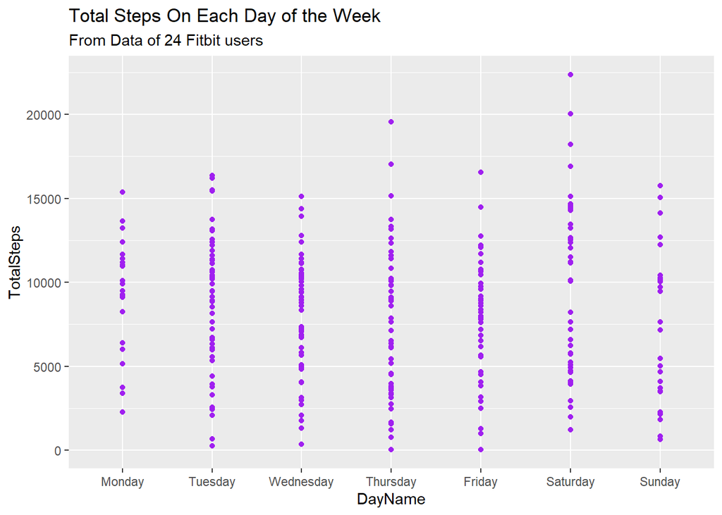

```r
#VIZ.1:Total Steps on each day of the week
ggplot(mergedata2)+geom_point(mapping=aes(x=DayName,y=TotalSteps),color="Purple")+
  scale_x_discrete(limits=c("Monday","Tuesday","Wednesday","Thursday","Friday","Saturday","Sunday"))+
  labs(title = "Total Steps On Each Day of the Week",
       subtitle = "From Data of 24 Fitbit users")
```

##VIZ.2: Weekly steps taking pattern in a group of people who takes more than 8000 daily steps.

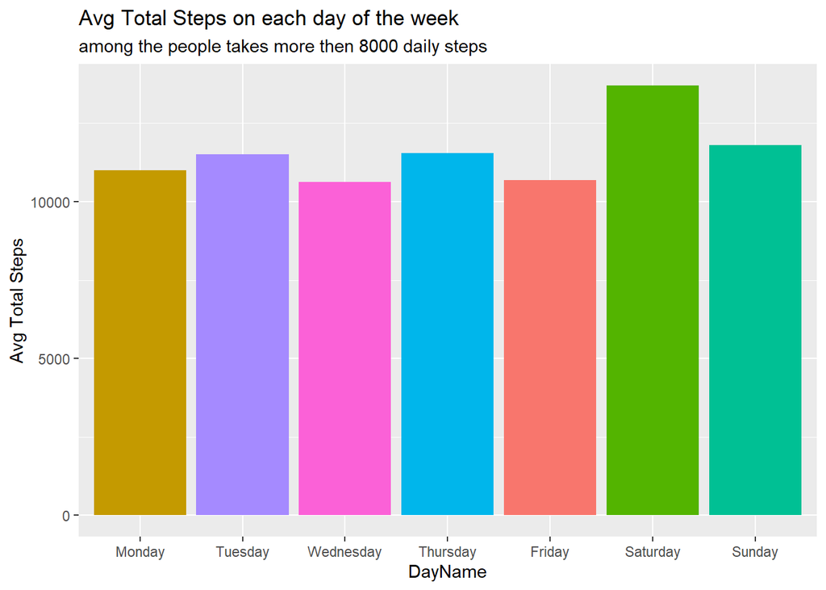

```r
mergedata2 %>%
  filter(TotalSteps>8000) %>%
  ggplot(mapping=aes(x=DayName,y=TotalSteps,fill=DayName))+
  geom_bar(stat="summary",fun="mean")+
  scale_x_discrete(limits=c("Monday","Tuesday","Wednesday","Thursday","Friday","Saturday","Sunday"))+
  labs(title="Avg Total Steps on each day of the week",
       subtitle = "among the people takes more then 8000 daily steps",
       y="Avg Total Steps")+
  theme(legend.position="none")
```

##VIZ.3: Steps pattern among those who takes less than 8000 daily steps.

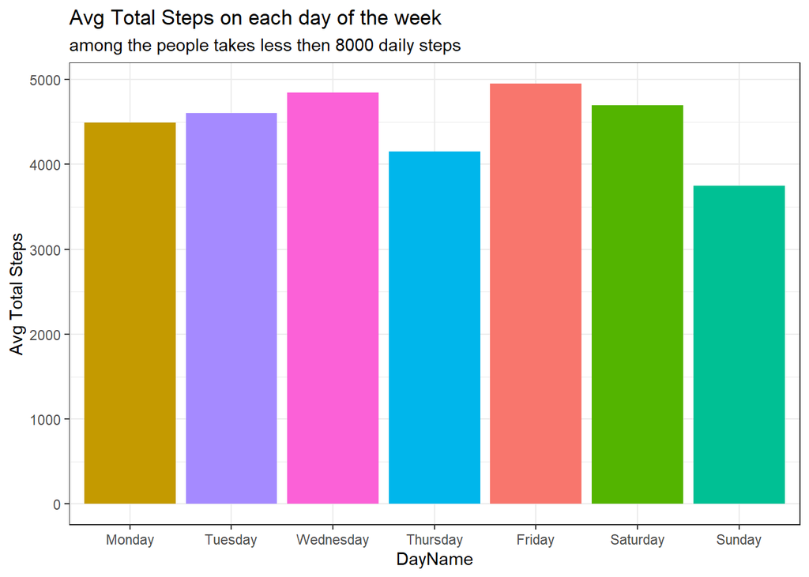

```r
theme_set(theme_bw())
mergedata2%>%
  filter(TotalSteps<8000) %>%
  ggplot(mapping=aes(x=DayName,y=TotalSteps,fill=DayName))+
  geom_bar(stat="summary",fun="mean")+
  scale_x_discrete(limits=c("Monday","Tuesday","Wednesday","Thursday","Friday","Saturday","Sunday"))+
  labs(title="Avg Total Steps on each day of the week",
       subtitle = "among the people takes less then 8000 daily steps",
       y="Avg Total Steps")+
  theme(legend.position="none")
```

##VIZ.4: Steps pattern among those who takes less than 5000 daily steps.

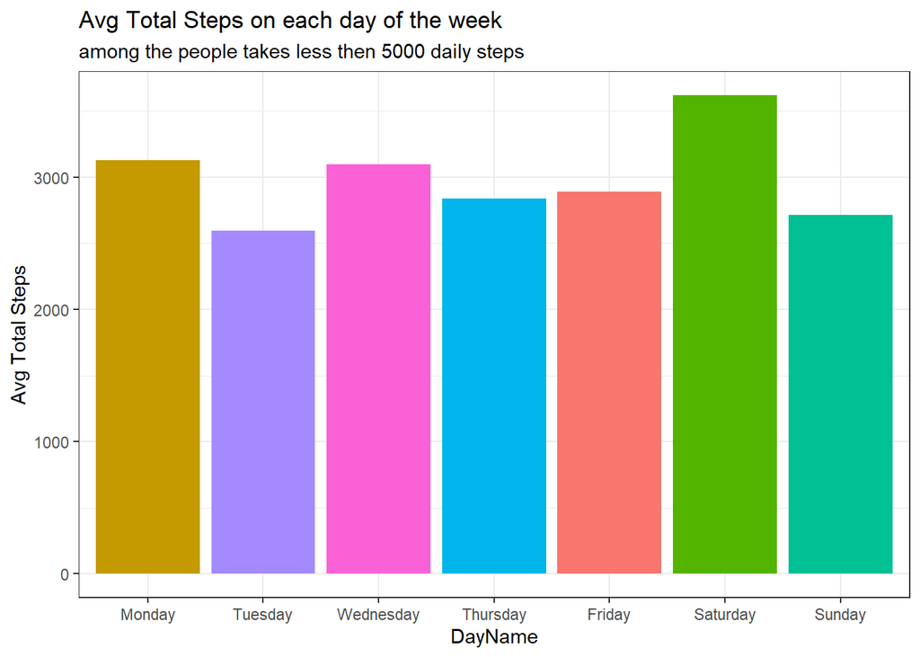

```r
mergedata2%>%
  filter(TotalSteps<5000) %>%
  ggplot(mapping=aes(x=DayName,y=TotalSteps,fill=DayName))+
  geom_bar(stat="summary",fun="mean")+
  scale_x_discrete(limits=c("Monday","Tuesday","Wednesday","Thursday","Friday","Saturday","Sunday"))+
  labs(title="Avg Total Steps on each day of the week",
       subtitle = "among the people takes less then 5000 daily steps",
       y="Avg Total Steps")+
  theme(legend.position="none")
```

##VIZ.5: Users consistency in steps and their BMI with 22 days Data of 6 Fitbit Users.

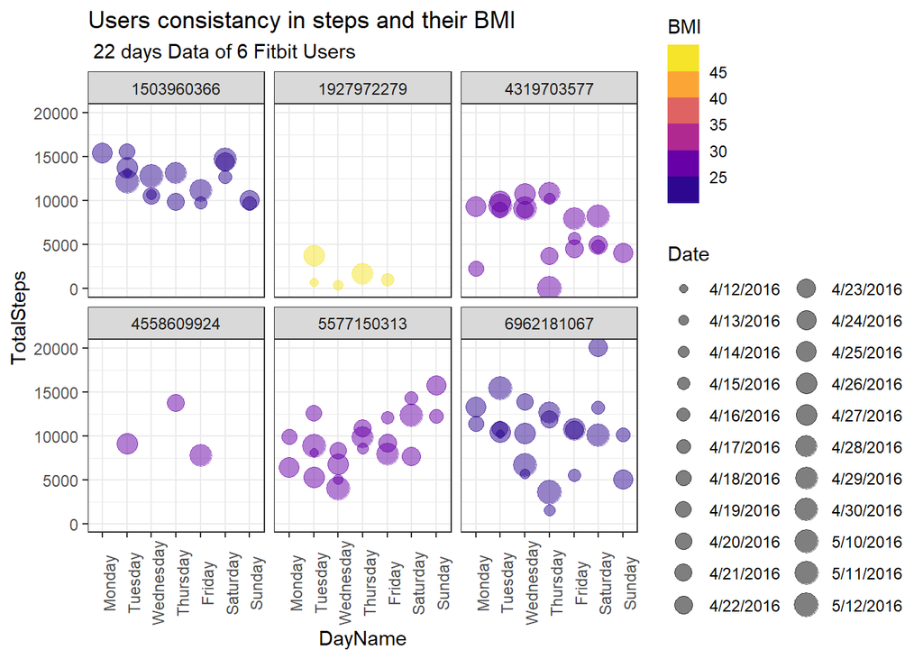

```r
mergeWt %>%
  ggplot(aes(DayName,TotalSteps,color=BMI,size=Date))+
  geom_point(alpha=0.5)+
  scale_x_discrete(limits = c("Monday" , "Tuesday", "Wednesday",
                              "Thursday" , "Friday" , "Saturday" , "Sunday"))+
  facet_wrap(~Id)+
  scale_color_viridis_b(option = "C")+
  theme(axis.text.x = element_text(angle = 90))+
  labs(title = "Users consistancy in steps and their BMI",
       subtitle = " 22 days Data of 6 Fitbit Users")
```

##VIZ.6: Users consistency in steps and their Sleep Pattern.

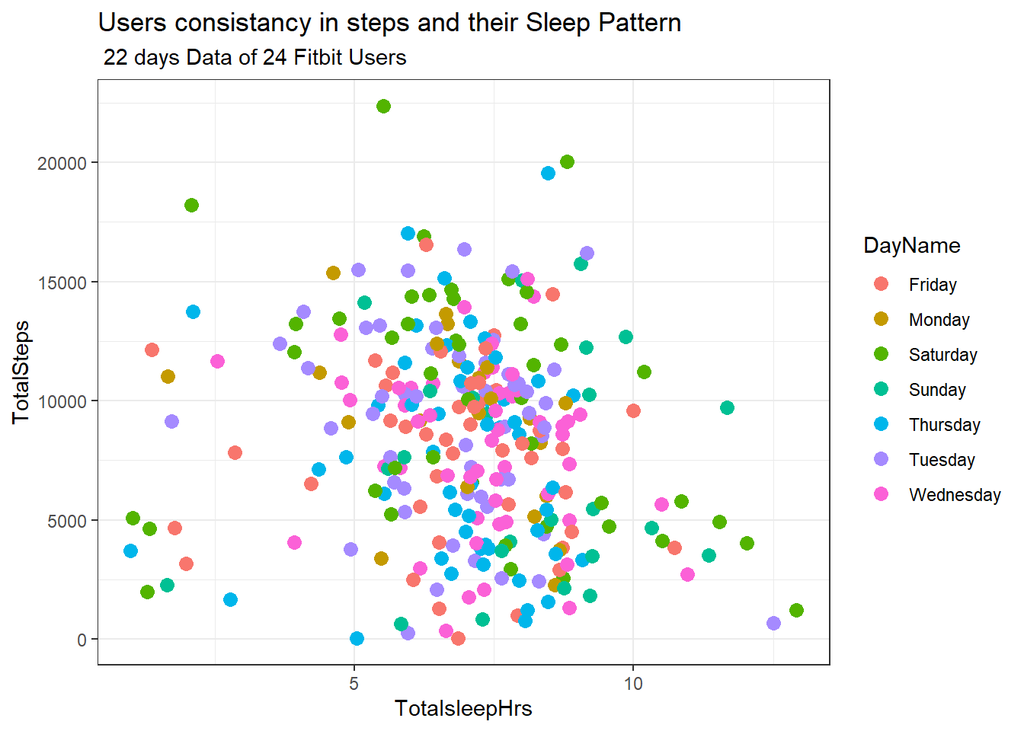

```r
ggplot(data=mergedata2) +
  geom_point(mapping = aes(x=TotalsleepHrs,y=TotalSteps,
                           color=DayName),size=3) +
  labs(title = "Users consistancy in steps and their Sleep Pattern",
       subtitle = " 22 days Data of 24 Fitbit Users")
```

##VIZ.7: 6 Users consistency in steps and their Sleep Pattern in 22 days time oeriod.

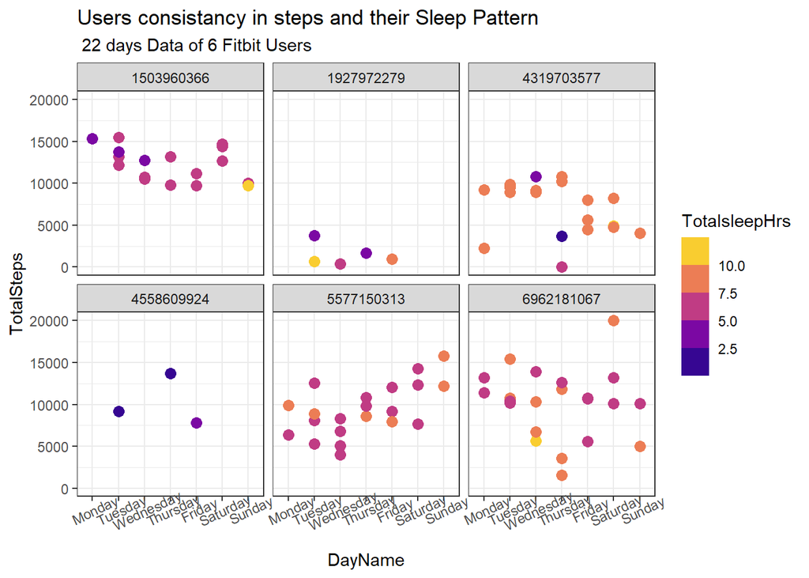

```r
mergeWt %>%
  ggplot(aes(DayName,TotalSteps,color=TotalsleepHrs))+
  geom_point(size=3)+
  scale_x_discrete(limits = c("Monday" , "Tuesday", "Wednesday",
                              "Thursday" , "Friday" , "Saturday" , "Sunday"))+
  facet_wrap(~Id)+
  scale_color_viridis_b(option = "C")+
  theme(axis.text.x = element_text(angle = 25))+
  labs(title = "Users consistancy in steps and their Sleep Pattern",
       subtitle = " 22 days Data of 6 Fitbit Users")
```

##VIZ.8: Total bed time and total sleep time.

[figure not shown]

```r
ggplot(data=mergedata2) +
  geom_jitter(mapping = aes(x=TotalTimeInBedHrs,y=TotalsleepHrs,color=DayName)) +
  labs(title = "Total bed time and total sleep time On Each Day of the Week",
       subtitle = "From Data of 24 Fitbit users of 22 Days")+
  annotate("text",x=9,y=4,label="Less Sleeping Set",color="purple",
           fontface="bold",angle=30,size=4)
```

##VIZ.9: Relation between users daily calories burned and avg METs.

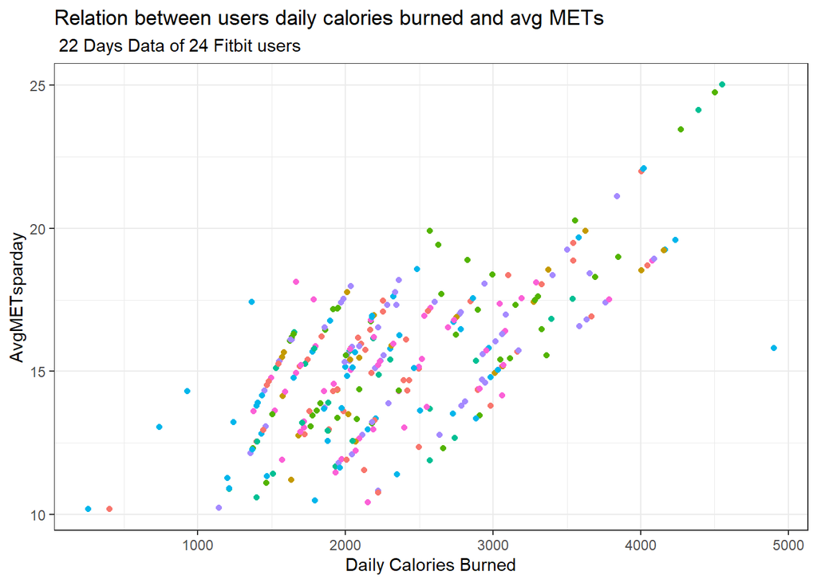

```r
ggplot(data=mergedata2) +
  geom_point(mapping = aes(x=Calories,y=AvgMETsparday,color=DayName)) +
  theme(legend.position = "none") +
  labs(title = "Relation between users daily calories burned and avg METs",
       subtitle = " 22 Days Data of 24 Fitbit users ",x="Daily Calories Burned")
```

##VIZ.10: Relation between users daily calories burned and Daily Sedentary Hrs.

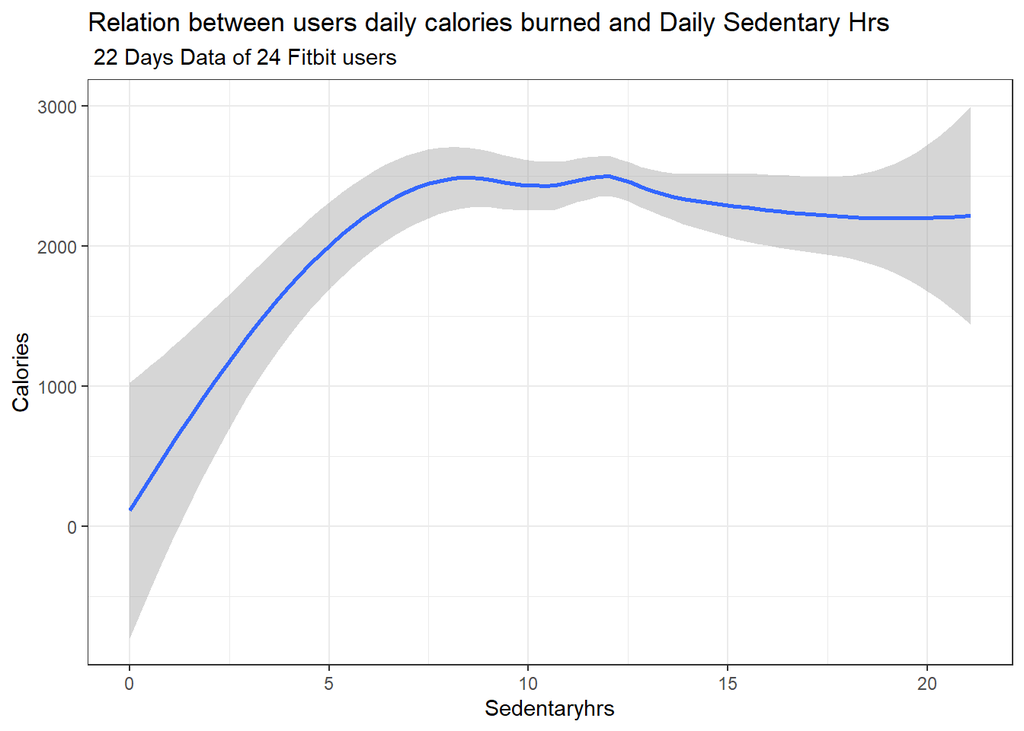

```r
ggplot(data=mergedata2) +
  geom_smooth(mapping = aes(x=Sedentaryhrs ,y=Calories)) +
  labs(title = "Relation between users daily calories burned and Daily Sedentary Hrs",
       subtitle = " 22 Days Data of 24 Fitbit users ")
```

##VIZ.11: Mean Workout Intensity Per Hour in a Day with 31 Days Data of 33 Fitbit Users.

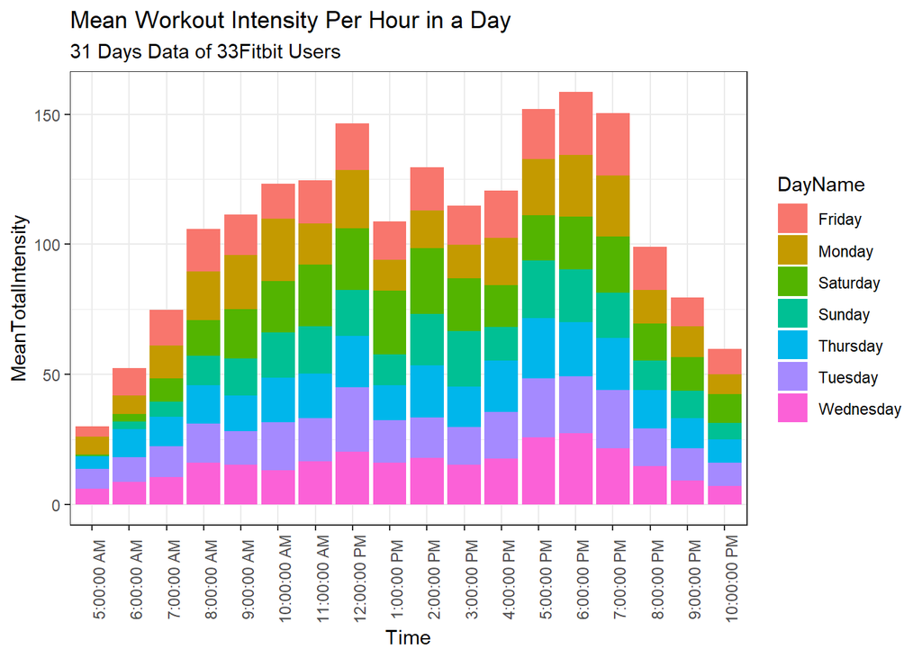

```r
ggplot(data = hourlyintensities,aes(x=Time,y=TotalIntensity,fill=DayName)) +
  geom_bar(stat = "summary",fun="mean") +
  theme(axis.text.x = element_text(angle = 90))+
  scale_x_discrete(limits = c("5:00:00 AM","6:00:00 AM","7:00:00 AM",
                              "8:00:00 AM","9:00:00 AM","10:00:00 AM",
                              "11:00:00 AM","12:00:00 PM","1:00:00 PM",
                              "2:00:00 PM","3:00:00 PM","4:00:00 PM",
                              "5:00:00 PM","6:00:00 PM","7:00:00 PM",
                              "8:00:00 PM","9:00:00 PM","10:00:00 PM" )) +
  labs(title = "Mean Workout Intensity Per Hour in a Day",y="MeanTotalIntensity",
       subtitle="31 Days Data of 33Fitbit Users")
```